# Analisis explorativo de datos Hidrológicos

*Sara Alvarado Siles*

### Introduccion

En el presente trabajo se utilizarán los datos hidrológicos de los caudales del río Estrella y el río Banano en el Caribe, mediante un FDC.csv (del íngles *Flow Durantion Curve*), trabajado con un formato en columnas.  
La columna A, corresponde a un listado de diferentes fechas de cuando se tomaron las medidas del cause, y las columnas B y C corresponden a información sobre algunos datos de una estación fluviográfica sobre los ríos correspondientes. Para este trabajo se utiliza el mm(*milimetro*), ya que, este corresponde a la unidad del balance hidrológico.

### Paso 1

Importar a R los datos que vamos a necesitar con la función:

> inp <- read.csv(“FDC.csv”, na.strings = "")

### Paso 2

En el caso de que se quiera visualizar solo los datos iniciales del documento se puede llamar a la función:

> head(inp)

La cual muestra la siguente información:

```
##      Tiempo Pandora.mm..637km2. Banano.mm..90km2.
## 1 6/22/1973                7.46             21.02
## 2 6/23/1973                6.17             14.78
## 3 6/24/1973                6.32             27.65
## 4 6/25/1973                7.80             19.68
## 5 6/26/1973                7.72             15.17
## 6 6/27/1973                7.83             23.14
```

### Paso 3

Para ver las dimensiones del archivo y saber cuantas columnas y filas tiene, se puede usar la función:

> dim(inp)

```
## [1] 3845    3
```

Esto quiere decir que hay *3845* filas y *3* columnas en este documento.

### Paso 4

Siempre es importante comprobar si hay celdas vacias, para esto utilizamos la función:

> inp[!complete.cases(inp),]

```
## [1] Tiempo              Pandora.mm..637km2. Banano.mm..90km2.
## <0 rows> (or 0-length row.names)
```

En este caso hay cero celdas vacias, lo que significa que trabajamos con una serie continua de datos.  
Si el documento presenta celdas vacias se puede utilizar la función:

> newinp <- na.omit(inp)

Esta elimina las filas donde en alguna columna aparezca un NA.

### Paso 5

Para observar rapidamente los datos del documento, creamos un gráfico simple con:

> plot(inp[,2], type = “l”, col = “blue”, main = “Volumen del agua en los ríos Estrella y Banano”,sub = “Datos tomados en un periodo de tiempo entre 1973 a 1983”, xlab = “Fechas”, ylab = “caudal en mm por día”) lines(inp[,3], col = “green”)

#### *Gráfico 1*

azul= río Estrella  
verde= río Banano

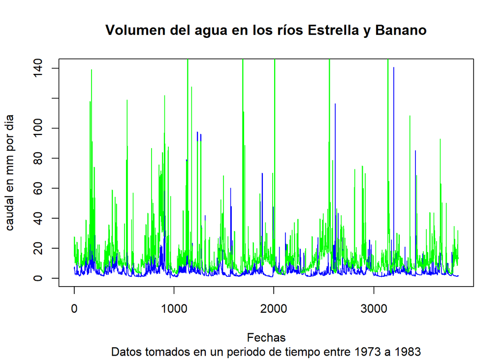

### Paso 6

> summary(inp[,2:3])

```
##  Pandora.mm..637km2. Banano.mm..90km2.
##  Min.   :  0.180     Min.   :  2.43
##  1st Qu.:  2.390     1st Qu.:  6.88
##  Median :  3.590     Median : 10.18
##  Mean   :  5.459     Mean   : 14.28
##  3rd Qu.:  5.900     3rd Qu.: 15.46
##  Max.   :140.650     Max.   :384.00
```

Los datos anteriores muestran como estan distribuidos los datos.

Podemos ver que el rio Banano a pesar de que tiene una cuenca mas pequeña que el rio Estrella, maneja una mayor cantidad de agua, por lo que, el río Banano es una mayor fuente de agua.

### Paso 7

También podemos observar la información en forma de histograma para ver de una manera mas clara como se distribuyen esos datos, para ello se aplican las siguientes funciones que corresponden al río Estrella y al río Banano, respectivamente:

> hist(inp[,2],main = “Histograma río Estrella”, xlab = “Rango absoluto de caudales”, ylab = “Frecuencia del caudal”)

> hist(inp[,3],main = “Histograma río Banano”, xlab = “Rango absoluto de caudales”, ylab = “Frecuencia del caudal”)

#### *Gráfico 2*

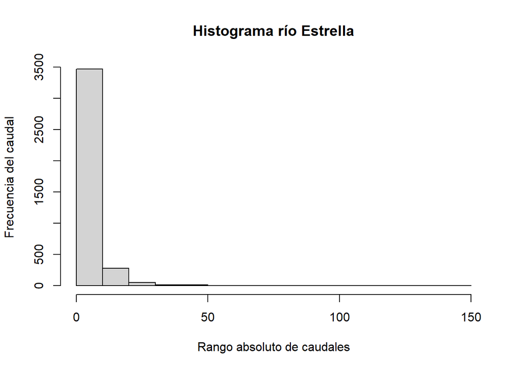

#### *Gráfico 3*

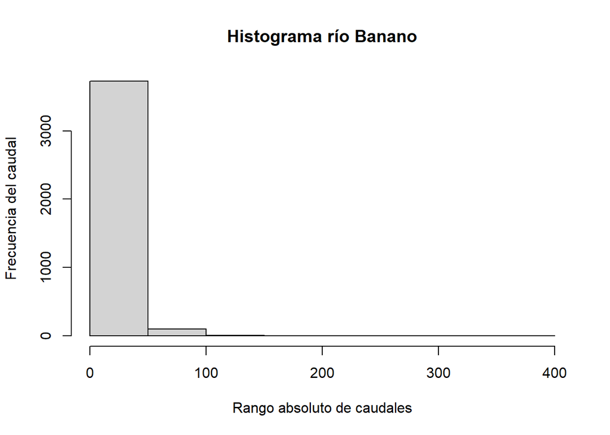

### Paso 8

Para manejar los datos de forma mas fácil es posible asignar nombres a los datos usando la siguiente función:

> names(inp) <- c(“fecha”, “Estrella”, “Banano”)  
> attach(inp)

El comando *attach()* ayuda hacer referencia a los nombres y encontrarlos mas facil.

#### *Gráfico 4*

Hacemos un gráfico para ver mejor los datos de los caudales del río Estrella.

> plot(Estrella, main = “Información sobre los caudales del río Estrella”, xlab = “Fechas”, ylab = “Rio Estrella”)

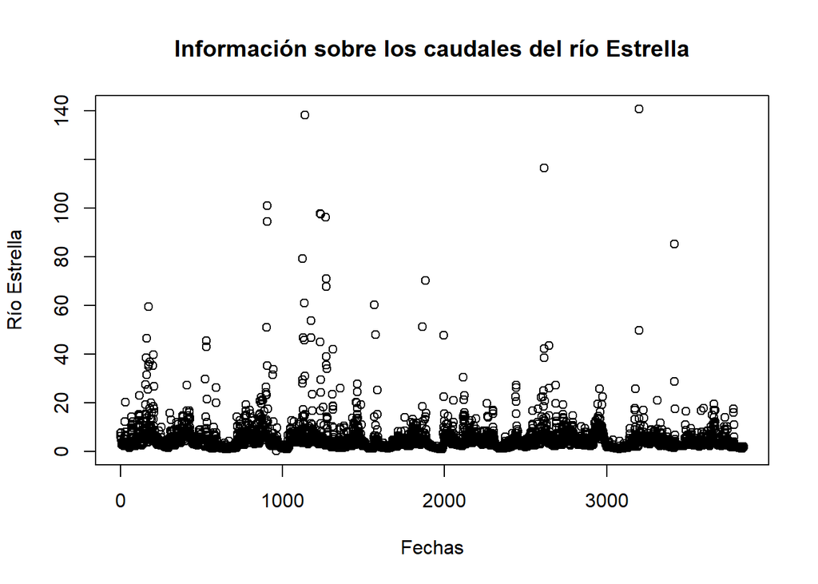

### Paso 9

Para definir las fechas, se llama a la función:

> Tempdate <- strptime(inp[,1], format = “%d/%m/%Y”)

### Paso 10

Esto lo hacemos con la función:

> MAQ_Estrella <- tapply(Estrella, format(Tempdate, format= “%Y”), FUN = sum)

> MAQ_Banano <- tapply(Banano, format(Tempdate, format= “%Y”), FUN = sum)

### Paso 11

Para exportar a .csv y guardar los datos de ambos rios en el directorio de trabajo, usamos la función:

> write.csv(rbind(MAQ_Estrella,MAQ_Banano), file=“MAQ.csv”)

El comando *rbing()* guarda los datos para visualisarlos en filas.  
En caso de que se quiera visualizar en columnas se puede utiliza el comando *cbing()*

### Paso 12

Para Visualizar rápidamente los valores anuales de los caudales en un gráfico y comparar directamente la información anterior, llamamos a la función:

> plot(MAQ_Banano, ylim = c(100, 3000), main = “Comparación anual de los caudales del río Estrella y el río Banano”, xlab = “Fechas”, ylab = “Caudales Anuales”)  
> lines(MAQ_Estrella, col=2)

#### *Gráfico 5*

Circulos=río Banano  
Lineas=río Estrella

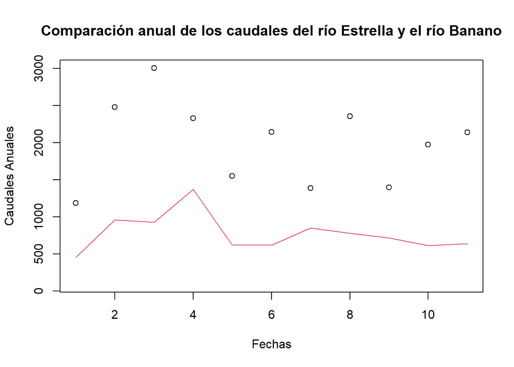

### Paso 13

> MMQ_Estrella <- tapply(Estrella, format(Tempdate, format= “%m”), FUN = sum)

> MMQ_Banano <- tapply(Banano, format(Tempdate, format= “%m”), FUN = sum)

#### *Gráfico 6*

La información anterior se puede visualizar en un gráfico con la función:

> plot(MMQ_Banano, ylim = c(100, 3000), main = “Comparación mensual de los caudales del rio Estrella y el rio Banano”, xlab = “Fechas”, ylab = “Caudales Mensuales”) lines(MMQ_Estrella, col=2)

Circulos=río Banano  
Lineas=río Estrella

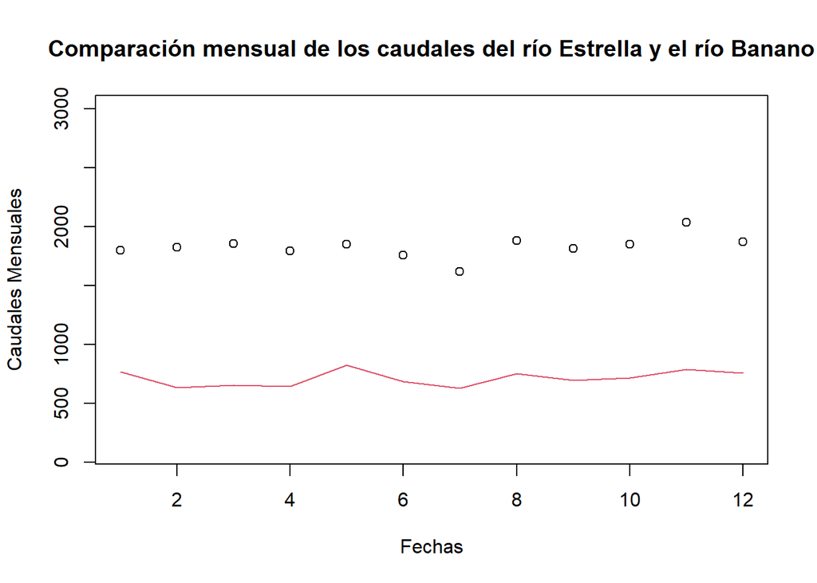

### Paso 14

Para calcular y analizar la correlación de los caudales del río Banano y el río Estrella, y determinar si existe hidroclimáticamente una relación cuantificable, utilizamos:

> corinp <- cor(inp[,2:3], method = “spearman”)  
> corinp

El procedimiento *sperman* es un método de correlación no paramétrico para datos ambientales.

```
##           Estrella    Banano
## Estrella 1.0000000 0.3720892
## Banano   0.3720892 1.0000000
```

Podemos observar que presentan una relación relativamente baja de 0.37 lo cual, es extraño, ya que, son cuencas vecinas. Esta información nos permite deducir que existen diferentes factores que influyen en la distribución del agua de esta zona como por ejemplo, la covertura, o la geología del lugar.

#### *Gráfico 7*

Creamos el gráfico para observar mejor los datos:

> plot(Estrella, Banano, main = “Correlación de los caudales del río Banano y el río Estrella”, xlab = “Río Estrella”, ylab = “Río Banano”)

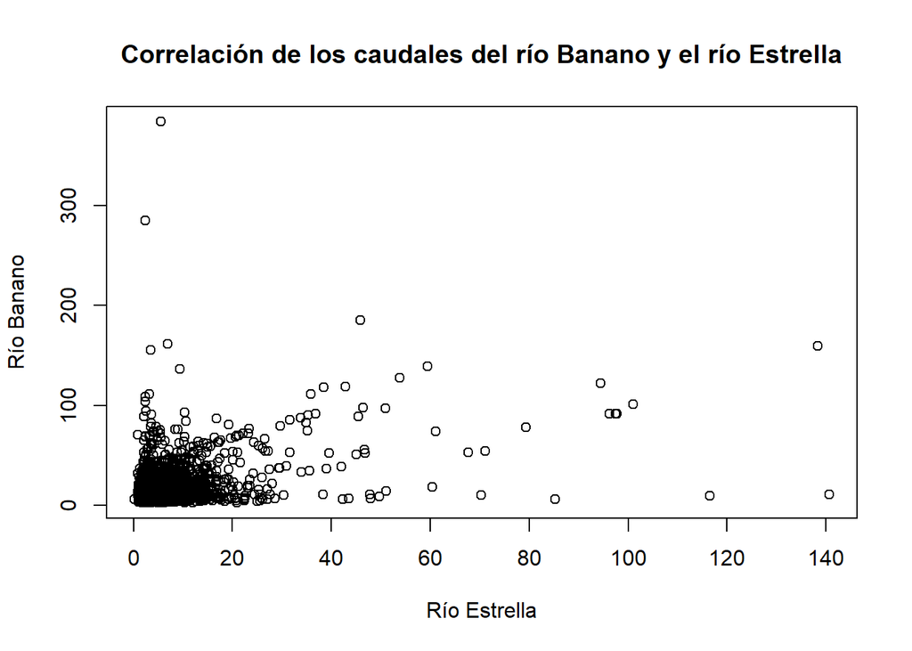

Esta información se puede exportar o crear una regresión, es decir, una cuantificación matemática de la correlación.

### Paso 15

Para crear un modelo de regresión lineal, llamamos a la función:

> inp.lm <- lm(inp[,2] ~ inp[,3], data = inp)  
> summary(inp.lm)

```
##
## Call:
## lm(formula = inp[, 2] ~ inp[, 3], data = inp)
##
## Residuals:
##     Min      1Q  Median      3Q     Max
## -71.297  -2.267  -1.155   0.774 135.889
##
## Coefficients:
##             Estimate Std. Error t value Pr(>|t|)
## (Intercept)  2.70503    0.15174   17.83   <2e-16 ***
## inp[, 3]     0.19290    0.00707   27.28   <2e-16 ***
## ---
## Signif. codes:  0 '***' 0.001 '**' 0.01 '*' 0.05 '.' 0.1 ' ' 1
##
## Residual standard error: 7.025 on 3843 degrees of freedom
## Multiple R-squared:  0.1623, Adjusted R-squared:  0.162
## F-statistic: 744.4 on 1 and 3843 DF,  p-value: < 2.2e-16
```

#### *Gráfico 8,9,10,11*

> plot(inp.lm)

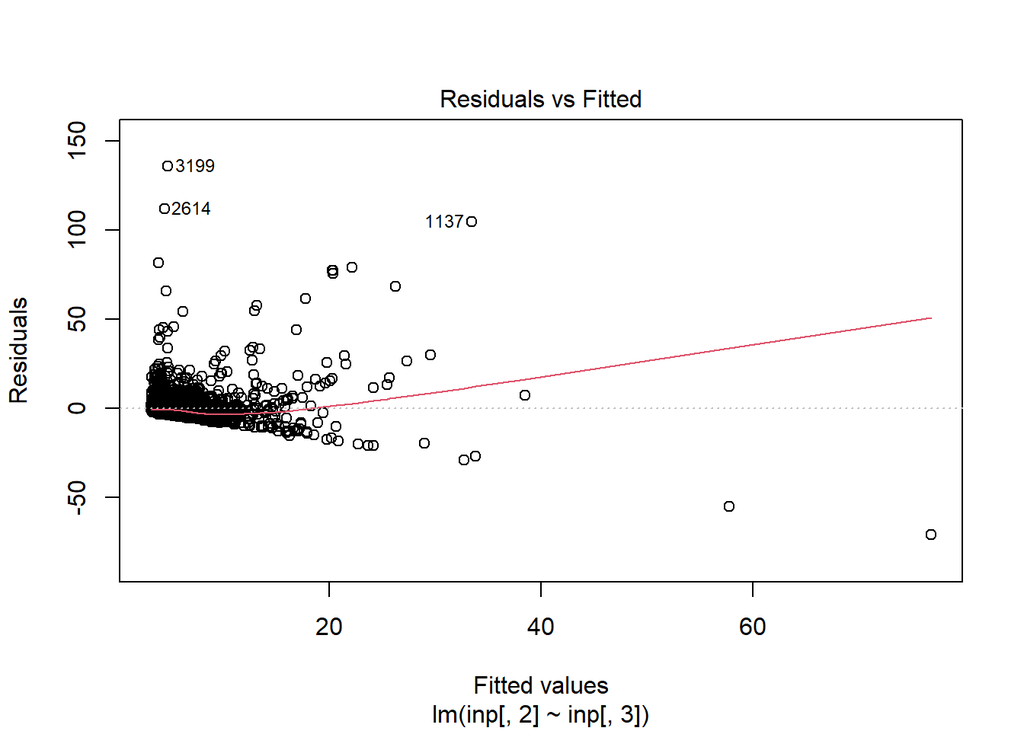

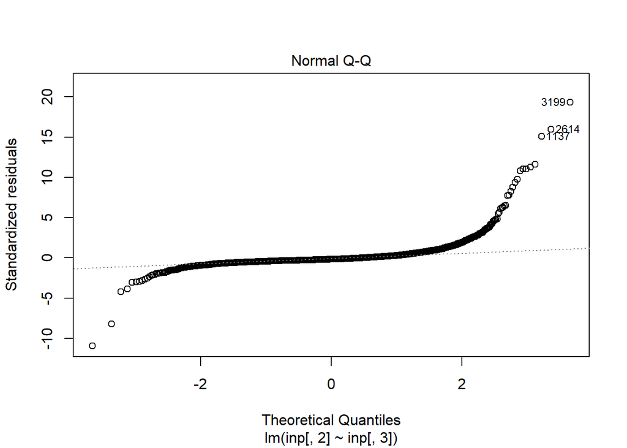

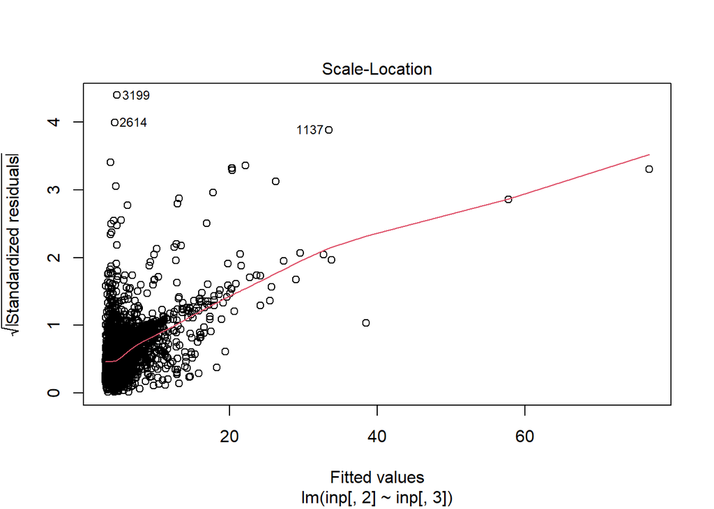

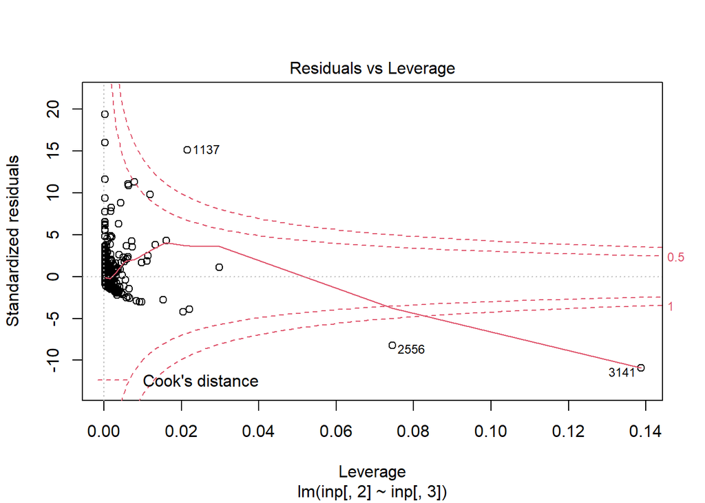

Toda la información que se analizó en el trabajo nos permite formular una idea sobre la cantidad de agua que recorre un río, o la cantidad de agua que huvo en un mes, entre muchos otros datos importantes.